# Football - Match Win Prediction

Naveen Kumar Kalluri | Ashok Kumar Rayapati | Varun Sai Rachulapally

4/27/2022

### About API:

We collected data from “football-data.org” API, where we are using data of 21353 records related to matches which are obtained from 157 competitions.

API source: https://www.football-data.org/documentation/quickstart

### Business Contex & Problem Description:

- To be able to predict the future winner is always exciting. We will try to predict the probability of a team winning the match based on their previous performances.
- By this, we want to address the problems faced by investors/organizations that are investing huge sums of money in the teams.

### Link to download data collected from API.

https://github.com/kumarrak/football

```r
rm(list = ls())
library(tidyverse)
library(caret)
library(httr)
library(glue)
library(magrittr)
library(purrr)
library(repurrrsive)
library(kableExtra)
library(data.table)
library(h2o)
library(e1071)
library(skimr)
library(recipes)
```

```r
library(stringr)
library(ggplot2)
library(ggthemes)
```

### Establishing a connection with API

```r
token = "ff9d3d9ab03f431aaf64ea00464e31a0"
football_api = GET("https://api.football-data.org//v2/competitions",
                   add_headers("X-Auth-Token"= token)
)

# connection
conn = content(football_api)
competitions = conn$competitions
```

### Data Description:

We collected 21353 records of data from 157 competitions using API.

Data Consists of 10 predictive variables they are:

halfTime_score_Home, halfTime_score_Away, fullTime_score_Home, fullTime_score_Away, homeTeam, awayTeam ,Odds.homeWin, Odds.draw, Odds.awayWin and winner.

Winner is the y variable to be predicted.

### All competitons data from API

```r
#Storing all competition id and their names in df
ids = map_int(competitions, ~.$id)
names = map_chr(competitions, ~.$name)

all_competitions = data.frame(id = ids, name = names)

#display all competitions
head(all_competitions, n=10) %>% kbl() %>% kable_minimal()
```

| id | name |
| --- | --- |
| 2006 | WC Qualification CAF |
| 2023 | Primera B Nacional |
| 2024 | Liga Profesional |
| 2025 | Supercopa Argentina |
| 2149 | Copa Liga Profesional |
| 2147 | WC Qualification AFC |
| 2008 | A League |
| 2026 | FFA Cup |
| 2020 | Erste Liga |
| 2012 | Bundesliga |

```r
#Selecting required competitions by their id's from the API

SelctCompetitions = c(all_competitions[1:157,])
# All selected competitions from above

selected_comps = SelctCompetitions


#display all available compts
#selected_comps

#Retrieving match data from the API
matches_data = list()


for(id in selected_comps$id){
  url = glue("http://api.football-data.org/v2/competitions/{id}/matches?dateFrom=2020-02-01&dateTo=2022-04-01")
  matches_comp = GET(url, add_headers("X-Auth-Token"= token))
  matches_data = append(matches_data, content(matches_comp))
}

all_matches = matches_data[names(matches_data) == "matches"]
#summary(all_matches)
```

### Collecting matches data from above competitions

#### Converting list of matches to a df.

```r
matches_df = data.frame()
for(x in 1:10){
  tbl <- as_tibble(all_matches)
  matches_df <- bind_rows(matches_df, unnest_wider(tbl,matches))
}
```

### Selecting the required columns

```r
matches_df <- subset (matches_df, select = -c(1,7,13))
```

```r
head(matches_df, n=10) %>% kbl() %>% kable_minimal()
```

| season | utcDate | status | matchday | stage | lastUpdated | odds | score | homeTeam | awayTeam |
| --- | --- | --- | --- | --- | --- | --- | --- | --- | --- |
| 589 , 2020-08-09, 2021-02-24, 38 | 2020-08-08T22:00:00Z | FINISHED | 1 | REGULAR_SEASON | 2020-08-11T07:32:35Z | 2.01, 3.24, 3.76 | AWAY_TEAM, REGULAR , 0 , 2 , 0 , 2 | 3984 , Fortaleza EC | 1768 , CA Paranaense |
| 589 , 2020-08-09, 2021-02-24, 38 | 2020-08-08T22:30:00Z | FINISHED | 1 | REGULAR_SEASON | 2020-08-11T07:32:35Z | 3.77, 3.06, 2.10 | AWAY_TEAM, REGULAR , 0 , 1 , 0 , 0 | 4241 , Coritiba FBC | 6684 , SC Internacional |
| 589 , 2020-08-09, 2021-02-24, 38 | 2020-08-09T00:00:00Z | FINISHED | 1 | REGULAR_SEASON | 2020-08-11T07:32:35Z | 2.90, 2.93, 2.60 | HOME_TEAM, REGULAR , 3 , 2 , 3 , 1 | 1778 , SC Recife | 1837 , Ceará SC |
| 589 , 2020-08-09, 2021-02-24, 38 | 2020-08-09T19:00:00Z | FINISHED | 1 | REGULAR_SEASON | 2020-08-12T09:32:37Z | 2.14, 3.24, 3.39 | DRAW , REGULAR, 1 , 1 , 0 , 0 | 6685 , Santos FC | 4286 , RB Bragantino |
| 589 , 2020-08-09, 2021-02-24, 38 | 2020-08-09T19:00:00Z | FINISHED | 1 | REGULAR_SEASON | 2020-08-12T09:32:37Z | 1.46, 4.46, 6.29 | AWAY_TEAM, REGULAR , 0 , 1 , 0 , 1 | 1783 , CR Flamengo | 1766 , CA Mineiro |
| 589 , 2020-08-09, 2021-02-24, 38 | 2020-08-09T22:00:00Z | FINISHED | 1 | REGULAR_SEASON | 2020-08-12T09:32:37Z | 1.58, 3.66, 6.12 | HOME_TEAM, REGULAR , 1 , 0 , 1 , 0 | 1767 , Grêmio FBPA | 1765 , Fluminense FC |
| 589 , 2020-08-09, 2021-02-24, 38 | 2020-08-12T22:15:00Z | FINISHED | 2 | REGULAR_SEASON | 2020-08-15T09:32:40Z | 1.98, 3.21, 3.99 | HOME_TEAM, REGULAR , 3 , 2 , 0 , 2 | 1766 , CA Mineiro | 1779 , SC Corinthians Paulista |
| 589 , 2020-08-09, 2021-02-24, 38 | 2020-08-12T22:15:00Z | FINISHED | 2 | REGULAR_SEASON | 2020-08-15T09:32:41Z | 1.27, 5.33, 9.88 | HOME_TEAM, REGULAR , 2 , 1 , 1 , 1 | 1768 , CA Paranaense | 4250 , Goiás EC |
| 589 , 2020-08-09, 2021-02-24, 38 | 2020-08-12T22:15:00Z | FINISHED | 2 | REGULAR_SEASON | 2020-08-15T09:32:41Z | 1.61, 3.75, 5.42 | DRAW , REGULAR, 1 , 1 , 1 , 0 | 4286 , RB Bragantino | 1770 , Botafogo FR |
| 589 , 2020-08-09, 2021-02-24, 38 | 2020-08-12T23:30:00Z | FINISHED | 2 | REGULAR_SEASON | 2020-08-15T09:32:41Z | 6.98, 4.34, 1.44 | HOME_TEAM, REGULAR , 3 , 0 , 2 , 0 | 3988 , AC Goianiense | 1783 , CR Flamengo |

### Data cleaning

```r
matches_df  <- matches_df %>%
  mutate(df = map(odds, ~ .x %>%
                    map_df(magrittr::extract,)))
```

```r
head(matches_df, n=10) %>% kbl() %>% kable_minimal()
```

| season | utcDate | status | matchday | stage | lastUpdated | odds | score | homeTeam | awayTeam | df |
| --- | --- | --- | --- | --- | --- | --- | --- | --- | --- | --- |
| 589 , 2020-08-09, 2021-02-24, 38 | 2020-08-08T22:00:00Z | FINISHED | 1 | REGULAR_SEASON | 2020-08-11T07:32:35Z | 2.01, 3.24, 3.76 | AWAY_TEAM, REGULAR , 0 , 2 , 0 , 2 | 3984 , Fortaleza EC | 1768 , CA Paranaense | 2.01, 3.24, 3.76 |
| 589 , 2020-08-09, 2021-02-24, 38 | 2020-08-08T22:30:00Z | FINISHED | 1 | REGULAR_SEASON | 2020-08-11T07:32:35Z | 3.77, 3.06, 2.10 | AWAY_TEAM, REGULAR , 0 , 1 , 0 , 0 | 4241 , Coritiba FBC | 6684 , SC Internacional | 3.77, 3.06, 2.10 |
| 589 , 2020-08-09, 2021-02-24, 38 | 2020-08-09T00:00:00Z | FINISHED | 1 | REGULAR_SEASON | 2020-08-11T07:32:35Z | 2.90, 2.93, 2.60 | HOME_TEAM, REGULAR , 3 , 2 , 3 , 1 | 1778 , SC Recife | 1837 , Ceará SC | 2.90, 2.93, 2.60 |
| 589 , 2020-08-09, 2021-02-24, 38 | 2020-08-09T19:00:00Z | FINISHED | 1 | REGULAR_SEASON | 2020-08-12T09:32:37Z | 2.14, 3.24, 3.39 | DRAW , REGULAR, 1 , 1 , 0 , 0 | 6685 , Santos FC | 4286 , RB Bragantino | 2.14, 3.24, 3.39 |
| 589 , 2020-08-09, 2021-02-24, 38 | 2020-08-09T19:00:00Z | FINISHED | 1 | REGULAR_SEASON | 2020-08-12T09:32:37Z | 1.46, 4.46, 6.29 | AWAY_TEAM, REGULAR , 0 , 1 , 0 , 1 | 1783 , CR Flamengo | 1766 , CA Mineiro | 1.46, 4.46, 6.29 |
| 589 , 2020-08-09, 2021-02-24, 38 | 2020-08-09T22:00:00Z | FINISHED | 1 | REGULAR_SEASON | 2020-08-12T09:32:37Z | 1.58, 3.66, 6.12 | HOME_TEAM, REGULAR , 1 , 0 , 1 , 0 | 1767 , Grêmio FBPA | 1765 , Fluminense FC | 1.58, 3.66, 6.12 |
| 589 , 2020-08-09, 2021-02-24, 38 | 2020-08-12T22:15:00Z | FINISHED | 2 | REGULAR_SEASON | 2020-08-15T09:32:40Z | 1.98, 3.21, 3.99 | HOME_TEAM, REGULAR , 3 , 2 , 0 , 2 | 1766 , CA Mineiro | 1779 , SC Corinthians Paulista | 1.98, 3.21, 3.99 |
| 589 , 2020-08-09, 2021-02-24, 38 | 2020-08-12T22:15:00Z | FINISHED | 2 | REGULAR_SEASON | 2020-08-15T09:32:41Z | 1.27, 5.33, 9.88 | HOME_TEAM, REGULAR , 2 , 1 , 1 , 1 | 1768 , CA Paranaense | 4250 , Goiás EC | 1.27, 5.33, 9.88 |
| 589 , 2020-08-09, 2021-02-24, 38 | 2020-08-12T22:15:00Z | FINISHED | 2 | REGULAR_SEASON | 2020-08-15T09:32:41Z | 1.61, 3.75, 5.42 | DRAW , REGULAR, 1 , 1 , 1 , 0 | 4286 , RB Bragantino | 1770 , Botafogo FR | 1.61, 3.75, 5.42 |
| 589 , 2020-08-09, 2021-02-24, 38 | 2020-08-12T23:30:00Z | FINISHED | 2 | REGULAR_SEASON | 2020-08-15T09:32:41Z | 6.98, 4.34, 1.44 | HOME_TEAM, REGULAR , 3 , 0 , 2 , 0 | 3988 , AC Goianiense | 1783 , CR Flamengo | 6.98, 4.34, 1.44 |

```r
matches_df  <- matches_df  %>%
  select(-odds) %>%
  unnest(df)
```

### Renaming the columns

```r
matches_df <- matches_df %>%
  dplyr::rename(
    Odds.homeWin = homeWin,
    Odds.draw = draw,
    Odds.awayWin = awayWin
  )
```

### Converting list data to a column (awayTeam column)

```r
matches_df  <- matches_df %>%
  mutate(df = map(awayTeam, ~ .x %>%
                    map_df(magrittr::extract,
                    )))
matches_df  <- matches_df  %>%
  select(-awayTeam) %>%
  unnest(df)

matches_df <- subset (matches_df, select = -c(id))

matches_df <- matches_df %>%
  dplyr::rename(
    awayTeam = name
  )
```

### Converting list data to a column (homeTeam column)

```r
matches_df  <- matches_df %>%
  mutate(df = map(homeTeam, ~ .x %>%
                    map_df(magrittr::extract,
                    )))

matches_df  <- matches_df  %>%
  select(-homeTeam) %>%
  unnest(df)

matches_df <- subset (matches_df, select = -c(id))
matches_df <- matches_df %>%
  dplyr::rename(
    homeTeam = name
  )
#head(matches_df, n=10) %>% kbl() %>% kable_minimal()
```

### full time and half time goals of the homeTeam and awayTeam

```r
scores = matches_df$score
winner_vector = map_chr(scores,"winner", .default = NA)

fullTimeScores = map(scores,"fullTime")
fTHome = map_int(fullTimeScores,"homeTeam", .default = NA)
fTAway = map_int(fullTimeScores,"awayTeam", .default = NA)

halfTimeScores = map(scores,"halfTime")
hTHome = map_int(halfTimeScores,"homeTeam", .default = NA)
hTAway = map_int(fullTimeScores,"awayTeam", .default = NA)


matches_df$halfTime_score_Home = hTHome
matches_df$halfTime_score_Away = hTAway
matches_df$fullTime_score_Home = fTHome
matches_df$fullTime_score_Away = fTAway
matches_df$winner = winner_vector

head(matches_df, n=10) %>% kbl() %>% kable_minimal()
```

| season | utcDate | status | matchday | stage | lastUpdated | score | Odds.homeWin | Odds.draw | Odds.awayWin | awayTeam | homeTeam | halfTime_score_Home | halfTime_score_Away | fullTime_score_Home | fullTime_score_Away | winner |
| --- | --- | --- | --- | --- | --- | --- | --- | --- | --- | --- | --- | --- | --- | --- | --- | --- |
| 589 , 2020-08-09, 2021-02-24, 38 | 2020-08-08T22:00:00Z | FINISHED | 1 | REGULAR_SEASON | 2020-08-11T07:32:35Z | AWAY_TEAM, REGULAR , 0 , 2 , 0 , 2 | 2.01 | 3.24 | 3.76 | CA Paranaense | Fortaleza EC | 0 | 2 | 0 | 2 | AWAY_TEAM |
| 589 , 2020-08-09, 2021-02-24, 38 | 2020-08-08T22:30:00Z | FINISHED | 1 | REGULAR_SEASON | 2020-08-11T07:32:35Z | AWAY_TEAM, REGULAR , 0 , 1 , 0 , 0 | 3.77 | 3.06 | 2.10 | SC Internacional | Coritiba FBC | 0 | 1 | 0 | 1 | AWAY_TEAM |
| 589 , 2020-08-09, 2021-02-24, 38 | 2020-08-09T00:00:00Z | FINISHED | 1 | REGULAR_SEASON | 2020-08-11T07:32:35Z | HOME_TEAM, REGULAR , 3 , 2 , 3 , 1 | 2.90 | 2.93 | 2.60 | Ceará SC | SC Recife | 3 | 2 | 3 | 2 | HOME_TEAM |
| 589 , 2020-08-09, 2021-02-24, 38 | 2020-08-09T19:00:00Z | FINISHED | 1 | REGULAR_SEASON | 2020-08-12T09:32:37Z | DRAW , REGULAR, 1 , 1 , 0 , 0 | 2.14 | 3.24 | 3.39 | RB Bragantino | Santos FC | 0 | 1 | 1 | 1 | DRAW |
| 589 , 2020-08-09, 2021-02-24, 38 | 2020-08-09T19:00:00Z | FINISHED | 1 | REGULAR_SEASON | 2020-08-12T09:32:37Z | AWAY_TEAM, REGULAR , 0 , 1 , 0 , 1 | 1.46 | 4.46 | 6.29 | CA Mineiro | CR Flamengo | 0 | 1 | 0 | 1 | AWAY_TEAM |
| 589 , 2020-08-09, 2021-02-24, 38 | 2020-08-09T22:00:00Z | FINISHED | 1 | REGULAR_SEASON | 2020-08-12T09:32:37Z | HOME_TEAM, REGULAR , 1 , 0 , 1 , 0 | 1.58 | 3.66 | 6.12 | Fluminense FC | Grêmio FBPA | 1 | 0 | 1 | 0 | HOME_TEAM |
| 589 , 2020-08-09, 2021-02-24, 38 | 2020-08-12T22:15:00Z | FINISHED | 2 | REGULAR_SEASON | 2020-08-15T09:32:40Z | HOME_TEAM, REGULAR , 3 , 2 , 0 , 2 | 1.98 | 3.21 | 3.99 | SC Corinthians Paulista | CA Mineiro | 0 | 2 | 3 | 2 | HOME_TEAM |
| 589 , 2020-08-09, 2021-02-24, 38 | 2020-08-12T22:15:00Z | FINISHED | 2 | REGULAR_SEASON | 2020-08-15T09:32:41Z | HOME_TEAM, REGULAR , 2 , 1 , 1 , 1 | 1.27 | 5.33 | 9.88 | Goiás EC | CA Paranaense | 1 | 1 | 2 | 1 | HOME_TEAM |
| 589 , 2020-08-09, 2021-02-24, 38 | 2020-08-12T22:15:00Z | FINISHED | 2 | REGULAR_SEASON | 2020-08-15T09:32:41Z | DRAW , REGULAR, 1 , 1 , 1 , 0 | 1.61 | 3.75 | 5.42 | Botafogo FR | RB Bragantino | 1 | 1 | 1 | 1 | DRAW |
| 589 , 2020-08-09, 2021-02-24, 38 | 2020-08-12T23:30:00Z | FINISHED | 2 | REGULAR_SEASON | 2020-08-15T09:32:41Z | HOME_TEAM, REGULAR , 3 , 0 , 2 , 0 | 6.98 | 4.34 | 1.44 | CR Flamengo | AC Goianiense | 2 | 0 | 3 | 0 | HOME_TEAM |

```r
football_df <- subset (matches_df, select = -c(score))

football_df <- football_df[, c("Odds.homeWin","Odds.draw","Odds.awayWin","halfTime_score_Home", "halfTime_score_Away","fullTime_score_Home", "fullTime_score_Away", "homeTeam", "awayTeam","winner")]
```

### Writing the data obtained to CSV

```r
head(football_df, n=10) %>% kbl() %>% kable_minimal()
```

| Odds.homeWin | Odds.draw | Odds.awayWin | halfTime_score_Home | halfTime_score_Away | fullTime_score_Home | fullTime_score_Away | homeTeam | awayTeam | winner |
| --- | --- | --- | --- | --- | --- | --- | --- | --- | --- |
| 2.01 | 3.24 | 3.76 | 0 | 2 | 0 | 2 | Fortaleza EC | CA Paranaense | AWAY_TEAM |
| 3.77 | 3.06 | 2.10 | 0 | 1 | 0 | 1 | Coritiba FBC | SC Internacional | AWAY_TEAM |
| 2.90 | 2.93 | 2.60 | 3 | 2 | 3 | 2 | SC Recife | Ceará SC | HOME_TEAM |
| 2.14 | 3.24 | 3.39 | 0 | 1 | 1 | 1 | Santos FC | RB Bragantino | DRAW |
| 1.46 | 4.46 | 6.29 | 0 | 1 | 0 | 1 | CR Flamengo | CA Mineiro | AWAY_TEAM |
| 1.58 | 3.66 | 6.12 | 1 | 0 | 1 | 0 | Grêmio FBPA | Fluminense FC | HOME_TEAM |
| 1.98 | 3.21 | 3.99 | 0 | 2 | 3 | 2 | CA Mineiro | SC Corinthians Paulista | HOME_TEAM |
| 1.27 | 5.33 | 9.88 | 1 | 1 | 2 | 1 | CA Paranaense | Goiás EC | HOME_TEAM |
| 1.61 | 3.75 | 5.42 | 1 | 1 | 1 | 1 | RB Bragantino | Botafogo FR | DRAW |
| 6.98 | 4.34 | 1.44 | 2 | 0 | 3 | 0 | AC Goianiense | CR Flamengo | HOME_TEAM |

```r
write.csv(football_df, file="football_api_data.csv", row.names = FALSE)
```

### reading data files and combining

```r
dff <- read.csv(file ="https://raw.githubusercontent.com/kumarrak/football/main/football_api_full.csv")

dff1 <- read.csv(file ="https://raw.githubusercontent.com/kumarrak/football/main/football_api_full1..csv")

dff2 <- read.csv(file ="https://raw.githubusercontent.com/kumarrak/football/main/football_api_full2.csv")

df_complete <- do.call('rbind', list(dff1, dff2, dff))
```

### Total No.of records before droping NA:

```r
nrow(df_complete)
```

```
## [1] 21353
```

### Drop rows with NA values

```r
colSums(is.na(df_complete))
```

```
##        Odds.homeWin           Odds.draw        Odds.awayWin halfTime_score_Home
##                   0                   0                   0                  93
## halfTime_score_Away fullTime_score_Home fullTime_score_Away            homeTeam
##                  84                  84                  84                   0
##            awayTeam              winner
##                   0                  84
```

```r
df_complete <- drop_na(df_complete)
view(df_complete)
```

### Total No.of records after cleaning: 21260

```r
nrow(df_complete)
```

```
## [1] 21260
```

### Converting character values to integer values in predictor column

```r
#Assessing the winner based on the outcome of the match
#0 = Draw match, 1 = Home team Win, 2 = Away team Win
df_complete$winner <- ifelse(df_complete$winner == "DRAW",0,df_complete$winner)
df_complete$winner <- ifelse(df_complete$winner == "HOME_TEAM",1,df_complete$winner)
df_complete$winner <- ifelse(df_complete$winner == "AWAY_TEAM",2,df_complete$winner)
df_complete$winner <- as.factor(df_complete$winner)
```

### Final dataset

```r
head(df_complete, n=10) %>% kbl() %>% kable_minimal()
```

| Odds.homeWin | Odds.draw | Odds.awayWin | halfTime_score_Home | halfTime_score_Away | fullTime_score_Home | fullTime_score_Away | homeTeam | awayTeam | winner |
| --- | --- | --- | --- | --- | --- | --- | --- | --- | --- |
| 2.01 | 3.24 | 3.76 | 0 | 2 | 0 | 2 | Fortaleza EC | CA Paranaense | 2 |
| 3.77 | 3.06 | 2.10 | 0 | 1 | 0 | 1 | Coritiba FBC | SC Internacional | 2 |
| 2.90 | 2.93 | 2.60 | 3 | 2 | 3 | 2 | SC Recife | Ceará SC | 1 |
| 2.14 | 3.24 | 3.39 | 0 | 1 | 1 | 1 | Santos FC | RB Bragantino | 0 |
| 1.46 | 4.46 | 6.29 | 0 | 1 | 0 | 1 | CR Flamengo | CA Mineiro | 2 |
| 1.58 | 3.66 | 6.12 | 1 | 0 | 1 | 0 | Grêmio FBPA | Fluminense FC | 1 |
| 1.98 | 3.21 | 3.99 | 0 | 2 | 3 | 2 | CA Mineiro | SC Corinthians Paulista | 1 |
| 1.27 | 5.33 | 9.88 | 1 | 1 | 2 | 1 | CA Paranaense | Goiás EC | 1 |
| 1.61 | 3.75 | 5.42 | 1 | 1 | 1 | 1 | RB Bragantino | Botafogo FR | 0 |
| 6.98 | 4.34 | 1.44 | 2 | 0 | 3 | 0 | AC Goianiense | CR Flamengo | 1 |

### Plot 1

##### Count of Matche (Wins,draws) with respect to Home team and Away team

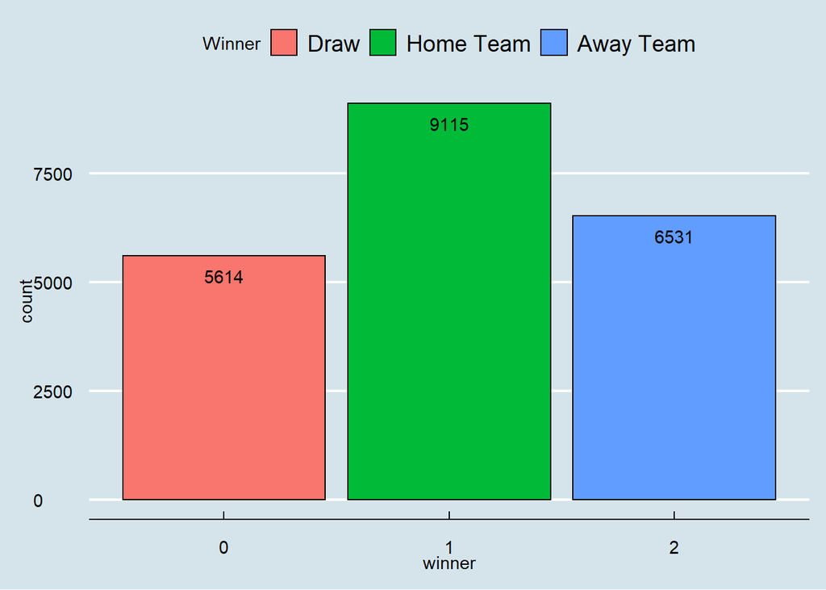

```r
ggplot(df_complete, aes(x=winner, fill=winner )) +
  geom_bar(colour="black")+
  geom_text( stat='count', aes(label=..count..), vjust= 2, position = position_dodge(.9) ) +
  theme_economist()+
  scale_fill_discrete(name = "Winner", labels = c("Draw", "Home Team", "Away Team"))
```

### Plot 2

##### Top Home Winners

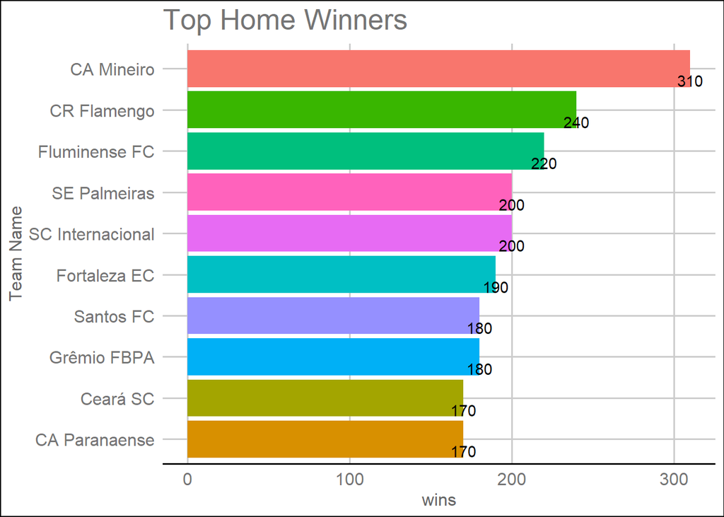

```r
homewins =subset(df_complete, winner==1) %>% count(homeTeam )
homewins <- homewins[with(homewins,order(-n)),]
homewins <- homewins[1:10,]



ggplot(data = homewins, aes(y = reorder(homeTeam, n), x = n, fill = homeTeam)) +
  geom_bar(stat = "identity", position = 'dodge')+
  geom_text(aes(label = n), vjust = 1.5, colour = "black")+
  theme(axis.text.x = element_text(angle = 90, vjust = 0.6))+
  xlab("wins") +
  ylab("Team Name")+
  theme_gdocs()+
  labs(title = "Top Home Winners")+
  theme(legend.position="none")
```

### Plot 3 ##### Top Away Winners

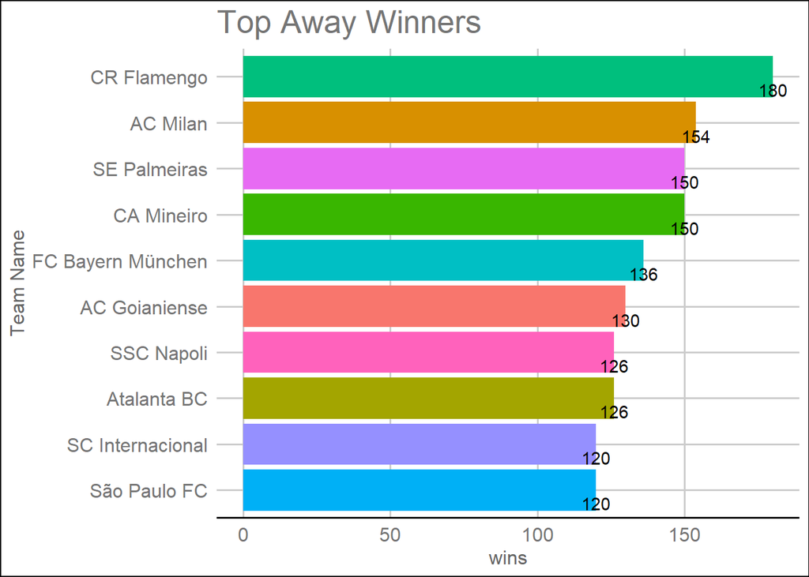

```r
awaywins =subset(df_complete, winner==2) %>% count(awayTeam )
awaywins <- awaywins[with(awaywins,order(-n)),]
awaywins <- awaywins[1:10,]

ggplot(data = awaywins, aes(y = reorder(awayTeam, n), x = n, fill = awayTeam)) +
  geom_bar(stat = "identity", position = 'dodge')+
  geom_text(aes(label = n), vjust = 1.5, colour = "black")+
  theme(axis.text.x = element_text(angle = 90, vjust = 0.6))+
  xlab("wins") +
  ylab("Team Name")+
  theme_gdocs()+
  labs(title = "Top Away Winners")+
  theme(legend.position="none")
```

### Plot 4

#### Top Three teams with respect to Home wins, Away wins and Draw

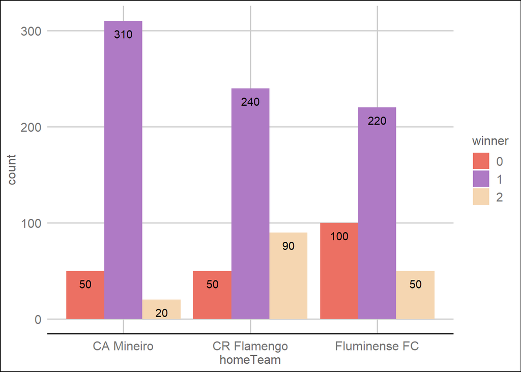

```r
count_homewins_top3 <- homewins[1:3,]
count_homewins_top3 <- count_homewins_top3[, c('homeTeam')]
three_team_df <- df_complete[, c('homeTeam', 'winner')] %>%
  filter(grepl('CA Mineiro|CR Flamengo|Fluminense FC', homeTeam))%>%
  group_by(homeTeam)

ggplot(three_team_df, aes(homeTeam)) +
  geom_bar(aes(fill = winner), position="dodge")+
  theme_gdocs()+
  theme(axis.text.x = element_text(angle = 0, vjust = 0.5))+
  geom_text( stat='count', aes(fill = winner, label=..count..), vjust= 2, position = position_dodge(.9) )+
  scale_fill_manual(values=c("#EC7063","#AF7AC5","#F5D6B1"))
```

### Split the dataset into train (80%) and test (20%).

##### Train Data

```r
set.seed(200)
trainIndex <- createDataPartition(df_complete$winner,p = 0.8,list = FALSE)

traindata <- df_complete[trainIndex,]
nrow(traindata)
```

```
## [1] 17009
```

```r
head(traindata, n=10) %>% kbl() %>% kable_minimal()
```

|  | Odds.homeWin | Odds.draw | Odds.awayWin | halfTime_score_Home | halfTime_score_Away | fullTime_score_Home | fullTime_score_Away | homeTeam | awayTeam | winner |
| --- | --- | --- | --- | --- | --- | --- | --- | --- | --- | --- |
| 1 | 2.01 | 3.24 | 3.76 | 0 | 2 | 0 | 2 | Fortaleza EC | CA Paranaense | 2 |
| 3 | 2.90 | 2.93 | 2.60 | 3 | 2 | 3 | 2 | SC Recife | Ceará SC | 1 |
| 4 | 2.14 | 3.24 | 3.39 | 0 | 1 | 1 | 1 | Santos FC | RB Bragantino | 0 |
| 5 | 1.46 | 4.46 | 6.29 | 0 | 1 | 0 | 1 | CR Flamengo | CA Mineiro | 2 |
| 6 | 1.58 | 3.66 | 6.12 | 1 | 0 | 1 | 0 | Grêmio FBPA | Fluminense FC | 1 |
| 7 | 1.98 | 3.21 | 3.99 | 0 | 2 | 3 | 2 | CA Mineiro | SC Corinthians Paulista | 1 |
| 8 | 1.27 | 5.33 | 9.88 | 1 | 1 | 2 | 1 | CA Paranaense | Goiás EC | 1 |
| 9 | 1.61 | 3.75 | 5.42 | 1 | 1 | 1 | 1 | RB Bragantino | Botafogo FR | 0 |
| 10 | 6.98 | 4.34 | 1.44 | 2 | 0 | 3 | 0 | AC Goianiense | CR Flamengo | 1 |
| 11 | 2.08 | 2.95 | 4.02 | 1 | 0 | 1 | 0 | EC Bahia | Coritiba FBC | 1 |

##### Test Data

```r
testdata <- df_complete[-trainIndex,]
nrow(testdata)
```

```
## [1] 4251
```

```r
head(testdata, n=10) %>% kbl() %>% kable_minimal()
```

|  | Odds.homeWin | Odds.draw | Odds.awayWin | halfTime_score_Home | halfTime_score_Away | fullTime_score_Home | fullTime_score_Away | homeTeam | awayTeam | winner |
| --- | --- | --- | --- | --- | --- | --- | --- | --- | --- | --- |
| 2 | 3.77 | 3.06 | 2.10 | 0 | 1 | 0 | 1 | Coritiba FBC | SC Internacional | 2 |
| 12 | 4.45 | 3.26 | 1.86 | 1 | 1 | 1 | 1 | Fluminense FC | SE Palmeiras | 0 |
| 22 | 3.08 | 3.10 | 2.37 | 0 | 1 | 2 | 1 | CR Vasco da Gama | São Paulo FC | 1 |
| 24 | 2.00 | 3.10 | 4.01 | 1 | 1 | 1 | 1 | AC Goianiense | SC Recife | 0 |
| 27 | 2.03 | 3.10 | 3.95 | 0 | 1 | 1 | 1 | CR Flamengo | Grêmio FBPA | 0 |
| 28 | 2.05 | 3.19 | 3.72 | 1 | 1 | 2 | 1 | RB Bragantino | Fluminense FC | 1 |
| 39 | 2.90 | 2.95 | 2.57 | 1 | 0 | 2 | 0 | Goiás EC | AC Goianiense | 1 |
| 45 | 2.11 | 3.11 | 3.67 | 1 | 0 | 2 | 0 | Ceará SC | EC Bahia | 1 |
| 54 | 2.27 | 2.93 | 3.42 | 0 | 0 | 1 | 0 | Coritiba FBC | SC Recife | 1 |
| 63 | 2.27 | 3.07 | 3.26 | 0 | 1 | 1 | 1 | SE Palmeiras | SC Internacional | 0 |

### Model Building

#### Naive Bayes Model

##### Fitting to training dataset

```r
nvclassifier <- naiveBayes(winner ~ ., data = traindata)
#nvclassifier

# Predicting on test data'
y_pred <- predict(nvclassifier, newdata = testdata)

# Confusion Matrix
cm <- table(testdata$winner, y_pred)
#cm

# Model Evaluation
confusionMatrix(cm)
```

```
## Confusion Matrix and Statistics
##
##    y_pred
##        0    1    2
##   0  899  109  114
##   1  583 1212   28
##   2  330   31  945
##
## Overall Statistics
##
##                Accuracy : 0.7189
##                  95% CI : (0.7051, 0.7324)
##     No Information Rate : 0.4263
##     P-Value [Acc > NIR] : < 2.2e-16
##
##                   Kappa : 0.582
##
##  Mcnemar's Test P-Value : < 2.2e-16
##
## Statistics by Class:
##
##                      Class: 0 Class: 1 Class: 2
## Sensitivity            0.4961   0.8964   0.8694
## Specificity            0.9086   0.7892   0.8859
## Pos Pred Value         0.8012   0.6648   0.7236
## Neg Pred Value         0.7082   0.9423   0.9518
## Prevalence             0.4263   0.3180   0.2557
## Detection Rate         0.2115   0.2851   0.2223
## Detection Prevalence   0.2639   0.4288   0.3072
## Balanced Accuracy      0.7024   0.8428   0.8776
```

### Organize the data:

#### Training data & Testing data

```r
x_train_tbl <- traindata %>% select(-winner)
y_train_tbl <- traindata %>% select(winner)
x_test_tbl <-testdata %>% select(-winner)
```

### Data inspection

```r
x_train_tbl_skim = partition(skim(x_train_tbl))
names(x_train_tbl_skim)
```

```
## [1] "character" "numeric"
```

### Data Wrangling

```r
string_2_factor_names <- x_train_tbl_skim$character$skim_variable
string_2_factor_names
```

```
## [1] "homeTeam" "awayTeam"
```

```r
unique_numeric_values_tbl <- x_train_tbl %>%
  select(x_train_tbl_skim$numeric$skim_variable) %>%
  map_df(~ unique(.) %>% length()) %>%
  gather() %>%
  arrange(value) %>%
  mutate(key = as_factor(key))
unique_numeric_values_tbl
```

```
## # A tibble: 7 x 2
##   key                 value
##   <fct>               <int>
## 1 halfTime_score_Home     6
## 2 halfTime_score_Away     9
## 3 fullTime_score_Away     9
## 4 fullTime_score_Home    10
## 5 Odds.draw             488
## 6 Odds.homeWin          675
## 7 Odds.awayWin          966
```

```r
factor_limit <- 25
num_2_factor_names <- unique_numeric_values_tbl %>%
  filter(value < factor_limit) %>%
  arrange(desc(value)) %>%
  pull(key) %>% # pull out a single variable as a vector
  as.character()
num_2_factor_names
```

```
## [1] "fullTime_score_Home" "halfTime_score_Away" "fullTime_score_Away"
## [4] "halfTime_score_Home"
```

### Recipes for ML Data Transformation

```r
rec_obj <- recipe(~ ., data = x_train_tbl) %>%
  step_string2factor(all_of(string_2_factor_names)) %>%
  step_num2factor(all_of(num_2_factor_names),
                  levels=str_c(0:1000),
                  transform = function(x) x + 1) %>%
  step_impute_mean(all_numeric()) %>% # missing values in numeric columns
  step_impute_mode(all_nominal()) %>% # missing values in factor columns
  prep(training = x_train_tbl)

rec_obj
```

```
## Data Recipe
##
## Inputs:
##
##       role #variables
##  predictor          9
##
## Training data contained 17009 data points and no missing data.
##
## Operations:
##
## Factor variables from homeTeam, awayTeam [trained]
## Factor variables from fullTime_score_Home, ... [trained]
## Mean Imputation for Odds.homeWin, Odds.draw, Odds.awayWin [trained]
## Mode Imputation for halfTime_score_Home, ... [trained]
```

### Start baking:

```r
x_train_processed_tbl <- bake(rec_obj, x_train_tbl)
x_test_processed_tbl <- bake(rec_obj, x_test_tbl)
```

### Transforming the outcome variable (y):

```r
rec_obj_for_y <- recipe(~ ., data = y_train_tbl) %>%
  prep(stringsAsFactors = FALSE)
y_train_processed_tbl <- bake(rec_obj_for_y, y_train_tbl)
```

### Deep Learning model using H2o

```r
h2o.init(nthreads = -1)
```

[output not shown]

```r
data_h2o <- as.h2o(
  bind_cols(y_train_processed_tbl, x_train_processed_tbl),
  destination_frame= "train.hex")
new_data_h2o <- as.h2o(
  x_test_processed_tbl,
  destination_frame= "test.hex"
)
data_h2o_no_destination <- as.h2o(
  bind_cols(y_train_processed_tbl, x_train_processed_tbl)
)
h2o.ls()
```

```
##                     key
## 1 data.frame_sid_87f1_3
## 2              test.hex
## 3             train.hex
```

### Splitting the training data into 3 subsets:

##### 70:15:15 split

```r
splits <- h2o.splitFrame(data = data_h2o, seed = 555,
                         ratios = c(0.7, 0.15))
train_h2o <- splits[[1]]
valid_h2o <- splits[[2]]
test_h2o <- splits[[3]]
```

### Deep Learning Model 1

```r
y <- "winner" # column name for outcome
x <- colnames(select(df_complete,-c('winner','homeTeam','awayTeam','fullTime_score_Home','fullTime_score_Away')))

m1 <- h2o.deeplearning(
  model_id = "dl_model_first",
  x = x,
  y = y,
  training_frame = train_h2o,
  validation_frame = valid_h2o,
  epochs = 1000
)
summary(m1)
```

```
## Model Details:
## ==============
##
## H2OMultinomialModel: deeplearning
## Model Key:  dl_model_first
## Status of Neuron Layers: predicting winner, 3-class classification, multinomial distribution, CrossEntropy loss, 45,003 weights/biases, 536.6 KB, 2,890,817 training samples, mini-batch size 1
##   layer units      type dropout       l1       l2 mean_rate rate_rms momentum
## 1     1    20     Input  0.00 %       NA       NA        NA       NA       NA
## 2     2   200 Rectifier  0.00 % 0.000000 0.000000  0.329676 0.451013 0.000000
## 3     3   200 Rectifier  0.00 % 0.000000 0.000000  0.157722 0.278638 0.000000
## 4     4     3   Softmax      NA 0.000000 0.000000  0.068425 0.205761 0.000000
##   mean_weight weight_rms mean_bias bias_rms
## 1          NA         NA        NA       NA
## 2   -0.038546   0.239907  0.005223 0.175624
## 3    0.001839   0.239259 -0.502684 0.537266
## 4   -0.396523   0.950019 -1.040725 0.974747
##
## H2OMultinomialMetrics: deeplearning
## ** Reported on training data. **
## ** Metrics reported on temporary training frame with 10007 samples **
##
## Training Set Metrics:
## =====================
##
## MSE: (Extract with `h2o.mse`) 0.1543834
## RMSE: (Extract with `h2o.rmse`) 0.3929165
## Logloss: (Extract with `h2o.logloss`) 0.4465479
## Mean Per-Class Error: 0.2470273
## AUC: (Extract with `h2o.auc`) NaN
## AUCPR: (Extract with `h2o.aucpr`) NaN
## Confusion Matrix: Extract with `h2o.confusionMatrix(<model>,train = TRUE)`)
## =========================================================================
## Confusion Matrix: Row labels: Actual class; Column labels: Predicted class
##           0    1    2  Error             Rate
## 0      1338  694  559 0.4836 =  1,253 / 2,591
## 1       477 3568  327 0.1839 =    804 / 4,372
## 2       191   33 2820 0.0736 =    224 / 3,044
## Totals 2006 4295 3706 0.2279 = 2,281 / 10,007
##
## Hit Ratio Table: Extract with `h2o.hit_ratio_table(<model>,train = TRUE)`
```

[output cut: 159 more lines]

```
## 6    0.075439
## 7    0.067320
## 8    0.064892
## 9    0.057092
## 10   0.050823
## 11   0.043784
## 12   0.039760
## 13   0.037831
## 14   0.030387
## 15   0.030337
## 16   0.029620
## 17   0.028243
## 18   0.025924
## 19   0.000000
## 20   0.000000
```

### Deep Learning Model 2

#### After tuning

```r
m2 <- h2o.deeplearning(
  model_id="dl_model_tuned",
  x = x,
  y = y,
  training_frame = train_h2o,
  validation_frame = valid_h2o,
  overwrite_with_best_model = F, ## Return the final model after 100 epochs,
  ## even if not the best
  hidden = c(150,150,150), ## more hidden layers -> more complex interactions
  epochs = 50,
  score_validation_samples = 10000, ## downsample validation set for faster scoring
  score_duty_cycle = 0.025, ## don't score more than 2.5% of the wall time
  adaptive_rate = F, ## manually tuned learning rate
  rate = 0.01,
  rate_annealing = 2e-6,
  momentum_start = 0.2, ## manually tuned momentum
  momentum_stable = 0.4,
  momentum_ramp = 1e7,
  l1 = 1e-5, ## add some L1/L2 regularization
  l2 = 1e-5,
  max_w2 = 10 ## helps stability for Rectifier
)
summary(m2)
```

```
## Model Details:
## ==============
##
## H2OMultinomialModel: deeplearning
## Model Key:  dl_model_tuned
## Status of Neuron Layers: predicting winner, 3-class classification, multinomial distribution, CrossEntropy loss, 48,903 weights/biases, 390.7 KB, 609,111 training samples, mini-batch size 1
##   layer units      type dropout       l1       l2 mean_rate rate_rms momentum
## 1     1    20     Input  0.00 %       NA       NA        NA       NA       NA
## 2     2   150 Rectifier  0.00 % 0.000010 0.000010  0.004508 0.000000 0.212182
## 3     3   150 Rectifier  0.00 % 0.000010 0.000010  0.004508 0.000000 0.212182
## 4     4   150 Rectifier  0.00 % 0.000010 0.000010  0.004508 0.000000 0.212182
## 5     5     3   Softmax      NA 0.000010 0.000010  0.004508 0.000000 0.212182
##   mean_weight weight_rms mean_bias bias_rms
## 1          NA         NA        NA       NA
## 2   -0.014728   0.196934  0.299444 0.079932
## 3   -0.019508   0.083829  0.911312 0.037707
## 4   -0.030139   0.097311  0.905047 0.044183
## 5   -0.002521   0.249089 -0.020470 0.092805
##
## H2OMultinomialMetrics: deeplearning
## ** Reported on training data. **
## ** Metrics reported on temporary training frame with 10011 samples **
##
## Training Set Metrics:
## =====================
##
## MSE: (Extract with `h2o.mse`) 0.1837328
## RMSE: (Extract with `h2o.rmse`) 0.4286406
## Logloss: (Extract with `h2o.logloss`) 0.5133033
## Mean Per-Class Error: 0.3010079
## AUC: (Extract with `h2o.auc`) NaN
## AUCPR: (Extract with `h2o.aucpr`) NaN
## Confusion Matrix: Extract with `h2o.confusionMatrix(<model>,train = TRUE)`)
## =========================================================================
## Confusion Matrix: Row labels: Actual class; Column labels: Predicted class
##           0    1    2  Error             Rate
## 0      1290 1052  338 0.5187 =  1,390 / 2,680
## 1       556 3560  172 0.1698 =    728 / 4,288
## 2       649    4 2390 0.2146 =    653 / 3,043
## Totals 2495 4616 2900 0.2768 = 2,771 / 10,011
```

[output cut: 116 more lines]

```
## 6    0.057871
## 7    0.054839
## 8    0.054682
## 9    0.054577
## 10   0.052806
## 11   0.050954
## 12   0.050345
## 13   0.049144
## 14   0.043181
## 15   0.042575
## 16   0.035166
## 17   0.034827
## 18   0.032583
## 19   0.000000
## 20   0.000000
```

### Hyper-parameter tuning with grid search

```r
hyper_params <- list(
  hidden = list( c(150,150,150), c(60,60) ),
  input_dropout_ratio = c(0, 0.05),
  rate = c(0.01, 0.02),
  rate_annealing = c(1e-8, 1e-7, 1e-6)
)

grid <- h2o.grid(
  algorithm="deeplearning",
  grid_id="dl_grid",
  x = x,
  y = y,
  training_frame = train_h2o,
  validation_frame = valid_h2o,
  epochs = 50,
  stopping_metric = "misclassification",
  stopping_tolerance = 1e-2,
  stopping_rounds = 2,
  score_validation_samples = 10000, ## downsample validation set for faster scoring
  score_duty_cycle = 0.025, ## don't score more than 2.5% of the wall time
  adaptive_rate = F, #manually tuned learning rate
  momentum_start = 0.5, #manually tuned momentum
  momentum_stable = 0.9,
  momentum_ramp = 1e7,
  l1 = 1e-5,
  l2 = 1e-5,
  activation = c("Rectifier"),
  max_w2 = 10, #can help improve stability for Rectifier
  hyper_params = hyper_params
)
grid <- h2o.getGrid("dl_grid", sort_by="logloss", decreasing=FALSE)
dl_grid_summary_table <- grid@summary_table
dl_grid_summary_table
```

```
## Hyper-Parameter Search Summary: ordered by increasing logloss
##            hidden input_dropout_ratio rate rate_annealing        model_ids
## 1 [150, 150, 150]                 0.0 0.02         1.0E-6 dl_grid_model_21
## 2 [150, 150, 150]                 0.0 0.02         1.0E-8  dl_grid_model_5
## 3        [60, 60]                 0.0 0.01         1.0E-6 dl_grid_model_18
## 4 [150, 150, 150]                0.05 0.02         1.0E-6 dl_grid_model_23
## 5 [150, 150, 150]                 0.0 0.01         1.0E-7  dl_grid_model_9
##              logloss
## 1 0.5124718876658286
## 2 0.5248476402415335
## 3 0.5300565383155106
## 4 0.5334646334500323
## 5 0.5343999275388982
##
## ---
##             hidden input_dropout_ratio rate rate_annealing        model_ids
## 19        [60, 60]                0.05 0.02         1.0E-7 dl_grid_model_16
## 20 [150, 150, 150]                0.05 0.02         1.0E-7 dl_grid_model_15
## 21        [60, 60]                0.05 0.01         1.0E-7 dl_grid_model_12
## 22        [60, 60]                0.05 0.02         1.0E-8  dl_grid_model_8
## 23        [60, 60]                 0.0 0.02         1.0E-8  dl_grid_model_6
## 24 [150, 150, 150]                0.05 0.02         1.0E-8  dl_grid_model_7
##               logloss
## 19  0.549448906066344
## 20  0.550325128556167
## 21 0.5540553405161665
## 22 0.5585337073751535
## 23 0.5600723304818438
## 24 0.5626503501527372
```

### To find best model in the grid

```r
dl_grid_best_model <- h2o.getModel(dl_grid_summary_table$model_ids[1])
summary(dl_grid_best_model)
```

```
## Model Details:
## ==============
##
## H2OMultinomialModel: deeplearning
## Model Key:  dl_grid_model_21
## Status of Neuron Layers: predicting winner, 3-class classification, multinomial distribution, CrossEntropy loss, 48,903 weights/biases, 390.7 KB, 620,178 training samples, mini-batch size 1
##   layer units      type dropout       l1       l2 mean_rate rate_rms momentum
## 1     1    20     Input  0.00 %       NA       NA        NA       NA       NA
## 2     2   150 Rectifier  0.00 % 0.000010 0.000010  0.012344 0.000000 0.524807
## 3     3   150 Rectifier  0.00 % 0.000010 0.000010  0.012344 0.000000 0.524807
## 4     4   150 Rectifier  0.00 % 0.000010 0.000010  0.012344 0.000000 0.524807
## 5     5     3   Softmax      NA 0.000010 0.000010  0.012344 0.000000 0.524807
##   mean_weight weight_rms mean_bias bias_rms
## 1          NA         NA        NA       NA
## 2   -0.039446   0.296822  0.115670 0.145748
## 3   -0.041352   0.105955  0.792847 0.110950
## 4   -0.052551   0.114938  0.778548 0.124343
## 5   -0.001457   0.248476 -0.084149 0.199057
##
## H2OMultinomialMetrics: deeplearning
## ** Reported on training data. **
## ** Metrics reported on temporary training frame with 10027 samples **
##
## Training Set Metrics:
## =====================
##
## MSE: (Extract with `h2o.mse`) 0.1800751
## RMSE: (Extract with `h2o.rmse`) 0.4243526
## Logloss: (Extract with `h2o.logloss`) 0.5004791
## Mean Per-Class Error: 0.3042386
## AUC: (Extract with `h2o.auc`) NaN
## AUCPR: (Extract with `h2o.aucpr`) NaN
## Confusion Matrix: Extract with `h2o.confusionMatrix(<model>,train = TRUE)`)
## =========================================================================
## Confusion Matrix: Row labels: Actual class; Column labels: Predicted class
##           0    1    2  Error             Rate
## 0       858 1126  658 0.6752 =  1,784 / 2,642
## 1       253 3711  343 0.1384 =    596 / 4,307
## 2       297    8 2773 0.0991 =    305 / 3,078
## Totals 1408 4845 3774 0.2678 = 2,685 / 10,027
```

[output cut: 111 more lines]

```
## 6    0.061483
## 7    0.057577
## 8    0.054369
## 9    0.054111
## 10   0.052562
## 11   0.052287
## 12   0.049270
## 13   0.046194
## 14   0.042534
## 15   0.035290
## 16   0.030581
## 17   0.025145
## 18   0.025142
## 19   0.000000
## 20   0.000000
```

### To find parameters used in the best model

```r
dl_grid_best_model_params <- dl_grid_best_model@allparameters
dl_grid_best_model_params
```

```
## $model_id
## [1] "dl_grid_model_21"
##
## $training_frame
## [1] "RTMP_sid_87f1_6"
##
## $validation_frame
## [1] "RTMP_sid_87f1_8"
##
## $nfolds
## [1] 0
##
## $keep_cross_validation_models
## [1] TRUE
##
## $keep_cross_validation_predictions
## [1] FALSE
##
## $keep_cross_validation_fold_assignment
## [1] FALSE
##
## $ignore_const_cols
## [1] TRUE
##
## $score_each_iteration
## [1] FALSE
##
## $balance_classes
## [1] FALSE
##
## $max_after_balance_size
## [1] 5
##
## $max_confusion_matrix_size
## [1] 20
##
## $overwrite_with_best_model
## [1] TRUE
##
## $use_all_factor_levels
```

[output cut: 179 more lines]

```
## $elastic_averaging_moving_rate
## [1] 0.9
##
## $elastic_averaging_regularization
## [1] 0.001
##
## $auc_type
## [1] "AUTO"
##
## $x
## [1] "halfTime_score_Away" "halfTime_score_Home" "Odds.homeWin"
## [4] "Odds.draw"           "Odds.awayWin"
##
## $y
## [1] "winner"
```

### AutoML in h2o

```r
automl_models_h2o <- h2o.automl(
  x = x,
  y = y,
  training_frame = train_h2o,
  validation_frame = valid_h2o,
  leaderboard_frame = test_h2o,
  max_runtime_secs = 200
)
```

```
##
## 13:20:30.707: User specified a validation frame with cross-validation still enabled. Please note that the models will still be validated using cross-validation only, the validation frame will be used to provide purely informative validation metrics on the trained models.
## 13:20:30.725: AutoML: XGBoost is not available; skipping it.
```

```r
automl_leaderboard <- automl_models_h2o@leaderboard
automl_leaderboard
```

```
##                                              model_id mean_per_class_error
## 1    StackedEnsemble_AllModels_AutoML_20220427_132030           0.06702360
## 2 StackedEnsemble_BestOfFamily_AutoML_20220427_132030           0.06862545
## 3                        DRF_1_AutoML_20220427_132030           0.07470077
## 4                        XRT_1_AutoML_20220427_132030           0.07618571
## 5          GBM_grid__1_AutoML_20220427_132030_model_1           0.09428664
## 6                        GBM_4_AutoML_20220427_132030           0.11695368
##     logloss      rmse        mse auc aucpr
## 1 0.1923829 0.2298598 0.05283554 NaN   NaN
## 2 0.2044860 0.2373447 0.05633249 NaN   NaN
## 3 0.2807445 0.2436539 0.05936722 NaN   NaN
## 4 0.3298142 0.2892166 0.08364627 NaN   NaN
## 5 0.2848550 0.2909293 0.08463983 NaN   NaN
## 6 0.3320854 0.3199132 0.10234446 NaN   NaN
##
## [17 rows x 7 columns]
```

```r
automl_leader <- automl_models_h2o@leader

performance_h2o <- h2o.performance(automl_leader, newdata = test_h2o)
performance_h2o %>%
  h2o.confusionMatrix()
```

```
## Confusion Matrix: Row labels: Actual class; Column labels: Predicted class
##          0    1   2  Error          Rate
## 0      617   41  31 0.1045 =    72 / 689
## 1       34  982  21 0.0530 =  55 / 1,037
## 2       27    7 747 0.0435 =    34 / 781
## Totals 678 1030 799 0.0642 = 161 / 2,507
```

### Shutdown the h2o:

```r
h2o.shutdown(prompt = F)
```

### Summary:

After splitting the dataset into 80% of traing data and the rest as testing data.

We have applied Naive Bayes model to the test data and got an accuracy of 72%.